# nlp

```python
import os

os.environ["KERAS_BACKEND"] = "tensorflow"

import keras
from keras.optimizers import SGD,Adam,AdamW
from keras.optimizers.schedules import PiecewiseConstantDecay
import tensorflow as tf
import numpy as np
from keras import layers
from tensorflow.keras import Input
```

[output not shown]

```python
import pandas as pd
```

```python
train = pd.read_csv("./datasets_p3/amazon_review_train.csv")
test = pd.read_csv("./datasets_p3/amazon_review_test.csv")
train.head()
```

|  | label | title | review |
| --- | --- | --- | --- |
| 0 | 1 | Excellent home help for parents | Volume 1 of Dolch Sight Work Activities for gr... |
| 1 | 0 | Stay far, far away. | I made it through about 6, maybe 7 minutes of ... |
| 2 | 0 | Lost Woods | Lost WoodsI didn't really understand the movie... |
| 3 | 0 | Renaissance -12, Women's brown suead shoes | Recomend ordering atleast 1/2 size to a full s... |
| 4 | 1 | Best Novel I've Read This Year | Intrigued by the variety of comments on Richar... |

```python
uniques = train["label"].unique()
uniques.shape[0]
```

```
2
```

# PREPROCESAMIENTO

Quitamos los nans, trasnformamos en arryas y quitamos mayusculas para reducir el vocab

```python
train = train.dropna()
train.shape
```

```
(71994, 3)
```

```python
test = test.dropna()
test.shape
```

```
(8000, 3)
```

### Poner los textos en minusculas

Para simplificar los datos a procesar se puede reducir el vocabulario quitando las mayusculas. A continuacion un ejemplo de como se haría a manera manual, sin embargo como la layer de vocabulario tambien hace este preprocesamiento se puede obviar

```python
if False:
    test["title"] = test["title"].map(str.lower)
    test["review"] = test["review"].map(str.lower)
    train["title"] = train["title"].map(str.lower)
    train["review"] = train["review"].map(str.lower)
    train.head(), stest.head()
```

```python
X = train.iloc[:,2].values
Y = train.iloc[:,0].values.reshape(-1,1)
X_test = test.iloc[:,2].values
Y_test = test.iloc[:,0].values.reshape(-1,1)
X[:2]
```

```
array(['Volume 1 of Dolch Sight Work Activities for grades K-1 covers 110 of the Dolch basic sight words, along with additional words from the Dolch Commomon Nouns List. Each of the 25 units includes lessons in letter tracing, matching and visualization, scrambled words, missing letters, sentence co…
       'I made it through about 6, maybe 7 minutes of this truly horrendous tripe. I suppose the saddest thing to see was improv veteran Andrea Martin, who apparently is not familiar with the difference between character and caricature, and is simply excruciating. Save what neurons you have and stay…
      dtype=object)
```

### FUNCIONES DE DIBUJADO

```python
from matplotlib import pyplot as plt

#historial = model1.fit()

def plot_accuracy(historiales, nombres, path):
    """
    Hace un plot de la evolucion de los accuracies segun los hitóricos del fit
    """
    for i, historial in enumerate(historiales):
        plt.plot(historial.history['accuracy'], label = nombres[i])
    #plt.plot(history.history['val_accuracy'])
    plt.title('model accuracy')
    plt.ylabel('accuracy')
    plt.xlabel('epoch')
    if len(historiales) < 13:
        plt.legend(loc='upper left')
    plt.savefig(f"Accuracy_{path}.png", bbox_inches='tight')
    plt.show()

def plot_loss(historiales, nombres, path):
    """
    Hace un plot de la evolucion de los losses segun los hitóricos del fit
    """
    for i, historial in enumerate(historiales):
        plt.plot(historial.history['loss'], label = nombres[i])
    #plt.plot(history.history['val_accuracy'])
    plt.title('model loss')
    plt.ylabel('loss')
    plt.xlabel('epoch')
    if len(historiales) < 13:
        plt.legend(loc='upper right')
    plt.savefig(f"Loss_{path}.png", bbox_inches='tight')
    plt.show()

def plot_test_accuracy(accuracies, nombres, path):
    """
    Hace un plot de los accuracies de los tests
    """
    plt.bar(x=nombres, height=accuracies, )
    #plt.plot(history.history['val_accuracy'])
    plt.title('model accuracy')
    plt.ylabel('accuracy')
    plt.xlabel('epoch')
    #plt.legend(loc='upper left')
    plt.savefig(f"Test_acc_{path}.png", bbox_inches='tight')
    plt.show()
```

## MODELO BASICO

Realizamos la codificacion (hardcode) de los datos que se piden para el modelo básico.

```python
keras.utils.set_random_seed(25)
```

```python
class modeloBasico:
    """
    Modelo básico con los parametros que se indican en el pdf

        - max_tokens: tamaño de vocabulario
        - output_sequence_length: tamaño maximo del texto de entrada
        - output_dim: dimensiones de salida de la capa de embeddings
        - units: numero de unidades de la capa recursiba
        - vocab: vocabulario al que adaptar la capa de vectorizacion de texto
    """
    def __init__(self,
                 max_tokens: int = 1000,
                 output_sequence_length: int = 50,
                 output_dim: int = 16,
                 units: int = 16,
                 vocab = None
                 ) -> None:
        self._tokenizer_l = layers.TextVectorization(
            max_tokens=max_tokens,
            output_sequence_length= output_sequence_length,
        )
        self._tokenizer_l.adapt(vocab)
        self._embedding_l = layers.Embedding(
            input_dim=max_tokens,
            output_dim=output_dim
        )
        self._rnn_l = layers.SimpleRNN(
            units=units,
        )
        self._dense_l = layers.Dense(1, activation="sigmoid")
        self.model = keras.Sequential(
            [self._tokenizer_l, self._embedding_l, self._rnn_l, self._dense_l]
        )
        self.model.compile(
            optimizer = "adam", loss="binary_crossentropy", metrics=["accuracy", keras.metrics.F1Score]
        )

    def summary(self):
        """
        Devuelve el summary de las capas del modelo
        """
        return self.model.summary()

    def fit(self, X, Y, epochs = 10, batch_size = 128):
        """
        Hace el fitting del modelo en base a X e Y. Devuelve el histórico del entrenamiento
        """
        return self.model.fit(
            X, Y,
            epochs=epochs,
            batch_size=batch_size,
        )

    def test(self, X_test, Y_test):
        """
        Devuelve el accuracy del test
        """
        #devuelve [loss, acc, extras] emtonces nos quedamos con el accuracy del test :D
        return self.model.evaluate(X_test, Y_test)[1]
```

```python
basic_model = modeloBasico(vocab=X)
```

[output not shown]

```python
Baseline_train = basic_model.fit(X, Y)
```

```
563/563 ━━━━━━━━━━━━━━━━━━━━ 4s 5ms/step - accuracy: 0.6608 - f1_score: 0.6666 - loss: 0.6019
563/563 ━━━━━━━━━━━━━━━━━━━━ 3s 5ms/step - accuracy: 0.7896 - f1_score: 0.6666 - loss: 0.4539
563/563 ━━━━━━━━━━━━━━━━━━━━ 3s 5ms/step - accuracy: 0.8006 - f1_score: 0.6666 - loss: 0.4327
563/563 ━━━━━━━━━━━━━━━━━━━━ 3s 5ms/step - accuracy: 0.8051 - f1_score: 0.6666 - loss: 0.4187
563/563 ━━━━━━━━━━━━━━━━━━━━ 3s 5ms/step - accuracy: 0.8115 - f1_score: 0.6666 - loss: 0.4065
563/563 ━━━━━━━━━━━━━━━━━━━━ 3s 5ms/step - accuracy: 0.8150 - f1_score: 0.6666 - loss: 0.3984
563/563 ━━━━━━━━━━━━━━━━━━━━ 3s 5ms/step - accuracy: 0.8181 - f1_score: 0.6666 - loss: 0.3919
563/563 ━━━━━━━━━━━━━━━━━━━━ 3s 5ms/step - accuracy: 0.8214 - f1_score: 0.6666 - loss: 0.3865
563/563 ━━━━━━━━━━━━━━━━━━━━ 3s 5ms/step - accuracy: 0.8260 - f1_score: 0.6666 - loss: 0.3792
563/563 ━━━━━━━━━━━━━━━━━━━━ 3s 5ms/step - accuracy: 0.8299 - f1_score: 0.6666 - loss: 0.3730
```

```python
Baseline_test = basic_model.test(X_test, Y_test)
```

```
250/250 ━━━━━━━━━━━━━━━━━━━━ 1s 2ms/step - accuracy: 0.7836 - f1_score: 0.6650 - loss: 0.4699
```

Dibujamos las gráficas

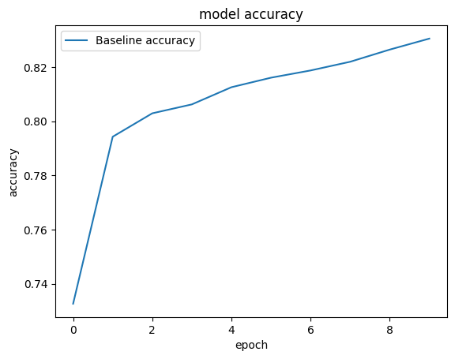

```python
plot_accuracy([Baseline_train], ["Baseline accuracy"], "baseline")
```

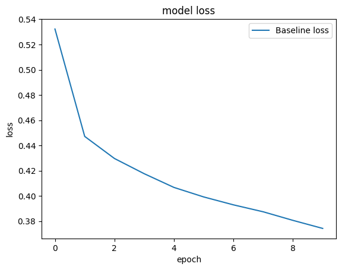

```python
plot_loss([Baseline_train], ["Baseline loss"], "baseline")
```

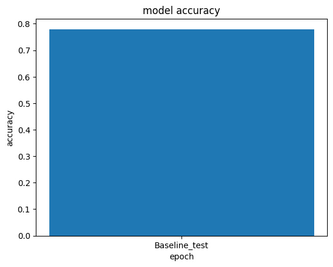

```python
plot_test_accuracy([Baseline_test], ["Baseline_test"], "baseline")
```

```python
Baseline_test
```

```
0.7796249985694885
```

A través de estos elementos podemos ver que el baseline sería el siguiente:

Podemos observar que con los parametros por defecto, nos aproximamos a un los de 0.37 y a una accuracy en el training de 0.83. Sin embargo, nuestra mética oficial baseline es de *0.78 de accuracy en el test*

## UPGRADE DEL MODELO

Lo primero que hacemos es recodificar la clase para permitir mayor variacion de argumentos

```python
class modeloConMejorasBasico:
    """
    Modelo diseñado para variar los parametros. Por defecto los valores son los del
    pdf

        - max_tokens: tamaño de vocabulario
        - output_sequence_length: tamaño maximo del texto de entrada
        - padding: indica si hace que el tamaño de salida de la capa de vectorización
        sea siempre el máximo
        - preprocessing: indica el tipo de preprocesamiento hacer en la capa de vectorizacion
        - output_dim: dimensiones de salida de la capa de embeddings
        - units: numero de unidades de la capa recursiba
        - vocab: vocabulario al que adaptar la capa de vectorizacion de texto
        - Recursive_LayerClass: clase que se usa para la recursión del modelo
        - Dropout: indica el dropount de las capas recursivas (por defecto 0)
        - ExtraLayers: array de capas extra a meter antes de la capa que colapsa
        para dos clases
    """
    def __init__(self,
                 max_tokens = 1000,
                 output_sequence_length = 50,
                 padding = False,
                 preprocessing = "lower_and_strip_punctuation",
                 output_dim = 16,
                 units = 16,
                 vocab = None,
                 Recursive_LayerClass = layers.SimpleRNN,
                 dropout = False,
                 ExtraLayers = [],
                 ) -> None:
        self._tokenizer_l = layers.TextVectorization(
            max_tokens=max_tokens,
            output_sequence_length= output_sequence_length,
            standardize = preprocessing,
            pad_to_max_tokens = padding
        )
        self._tokenizer_l.adapt(vocab)

        self._embedding_l = layers.Embedding(
            input_dim=max_tokens,
            output_dim=output_dim
        )

        self._recursive_layer = Recursive_LayerClass(
            units=units,
            recurrent_dropout = dropout if dropout is not None else 0,
            dropout = dropout if dropout is not None else 0,
        )

        self._collapse_layer = layers.Dense(1, activation="sigmoid")

        self.model: keras.Sequential = keras.Sequential(
            [self._tokenizer_l, self._embedding_l, self._recursive_layer, *ExtraLayers, self._collapse_layer]
        )

        self.model.compile(
            optimizer = "adam", loss="binary_crossentropy", metrics=["accuracy", keras.metrics.F1Score]
        )

    def summary(self):
        """
        Devuelve el summary de las capas del modelo
        """
        return self.model.summary()

    def fit(self, X, Y, epochs = 10, batch_size = 128):
        """
        Hace el fitting del modelo en base a X e Y. Devuelve el histórico del entrenamiento
        """
        return self.model.fit(
            X, Y,
            epochs=epochs,
            batch_size=batch_size,
        )

    def test(self, X_test, Y_test):
        """
        Devuelve el accuracy del test
        """
        #devuelve [loss, acc, extras] emtonces nos quedamos con el accuracy del test :D
        return self.model.evaluate(X_test, Y_test)[1]
```

Definimos una funcion para realizar pruebas:

```python
def test_all(params):
    """
    Funcion que crea un modelo con los paramentros, lo entrena, evalua el test y guarda los
    datos a partir de un array de parametros
    """

    results = {
        "history": [Baseline_train],
        "test_acc": [Baseline_test],
        "params": ["Por defecto"],
        "names": ["Baseline"],
    }
    for i, param_comb in enumerate(params):

        model = modeloConMejorasBasico(**param_comb, vocab=X)

        results["history"].append(model.fit(X, Y))

        results["test_acc"].append(model.test(X_test, Y_test))

        results["params"].append(param_comb)

        results["names"].append(f"p1_c_{i}")

    results["best_test_acc_index"] = np.argmax(results["test_acc"])
    results["best_test_acc"] = results["test_acc"][results["best_test_acc_index"]]
    results["best_params"] = results["params"][results["best_test_acc_index"]]

    return results
```

Definimos a mayores una funcion para conseguir todas las combinaciones de parametros:

```python
import itertools

def generate_param_combinations(dic):
    """
    Convierte un diccionario de arrays de parametros en un array de diccionarios de combinaciones
    """

    param_names = list(dic.keys())
    param_values = list(dic.values())
    combinations = list(itertools.product(*param_values))

    result = []
    for combo in combinations:
        param_dict = dict(zip(param_names, combo))
        result.append(param_dict)

    return result
```

#### Pruebas con el Vocabulario

Vamos a probar las siguientes posibles mejoras para el modelo: diferentes variaciones de max_tokens [256, 512, 1000, 1500], de sequence_length [25, 50, 75, 100], meterle padding y cambiar el preprocesamiento de la capa de Texto

Primero vamos a definir las combinaciones de parametros

```python
params_p1 = {
    "max_tokens": (256, 512, 1000, 1500),
    "output_sequence_length": (25, 50, 75, 100),
    "preprocessing": ("lower_and_strip_punctuation", "lower", "strip_punctuation", None),
    "padding": (False, True),
}
Comb_params_p1 = generate_param_combinations(params_p1)
```

```python
resultados_p1 = test_all(Comb_params_p1)
```

```
563/563 ━━━━━━━━━━━━━━━━━━━━ 3s 4ms/step - accuracy: 0.6351 - f1_score: 0.6666 - loss: 0.6291
563/563 ━━━━━━━━━━━━━━━━━━━━ 2s 4ms/step - accuracy: 0.6993 - f1_score: 0.6666 - loss: 0.5755
563/563 ━━━━━━━━━━━━━━━━━━━━ 2s 4ms/step - accuracy: 0.7046 - f1_score: 0.6666 - loss: 0.5643
563/563 ━━━━━━━━━━━━━━━━━━━━ 2s 4ms/step - accuracy: 0.7067 - f1_score: 0.6666 - loss: 0.5596
563/563 ━━━━━━━━━━━━━━━━━━━━ 2s 4ms/step - accuracy: 0.7103 - f1_score: 0.6666 - loss: 0.5557
563/563 ━━━━━━━━━━━━━━━━━━━━ 2s 3ms/step - accuracy: 0.7127 - f1_score: 0.6666 - loss: 0.5521
563/563 ━━━━━━━━━━━━━━━━━━━━ 2s 4ms/step - accuracy: 0.7145 - f1_score: 0.6666 - loss: 0.5487
563/563 ━━━━━━━━━━━━━━━━━━━━ 2s 4ms/step - accuracy: 0.7162 - f1_score: 0.6666 - loss: 0.5456
563/563 ━━━━━━━━━━━━━━━━━━━━ 2s 3ms/step - accuracy: 0.7176 - f1_score: 0.6666 - loss: 0.5429
563/563 ━━━━━━━━━━━━━━━━━━━━ 2s 4ms/step - accuracy: 0.7197 - f1_score: 0.6666 - loss: 0.5405
250/250 ━━━━━━━━━━━━━━━━━━━━ 0s 1ms/step - accuracy: 0.6907 - f1_score: 0.6650 - loss: 0.5711
563/563 ━━━━━━━━━━━━━━━━━━━━ 3s 3ms/step - accuracy: 0.5791 - f1_score: 0.6666 - loss: 0.6669
563/563 ━━━━━━━━━━━━━━━━━━━━ 2s 3ms/step - accuracy: 0.6945 - f1_score: 0.6666 - loss: 0.5789
563/563 ━━━━━━━━━━━━━━━━━━━━ 2s 3ms/step - accuracy: 0.7024 - f1_score: 0.6666 - loss: 0.5690
563/563 ━━━━━━━━━━━━━━━━━━━━ 2s 4ms/step - accuracy: 0.7061 - f1_score: 0.6666 - loss: 0.5645
563/563 ━━━━━━━━━━━━━━━━━━━━ 2s 4ms/step - accuracy: 0.7077 - f1_score: 0.6666 - loss: 0.5605
563/563 ━━━━━━━━━━━━━━━━━━━━ 3s 4ms/step - accuracy: 0.7111 - f1_score: 0.6666 - loss: 0.5567
563/563 ━━━━━━━━━━━━━━━━━━━━ 2s 4ms/step - accuracy: 0.7117 - f1_score: 0.6666 - loss: 0.5534
563/563 ━━━━━━━━━━━━━━━━━━━━ 2s 4ms/step - accuracy: 0.7132 - f1_score: 0.6666 - loss: 0.5503
563/563 ━━━━━━━━━━━━━━━━━━━━ 2s 4ms/step - accuracy: 0.7149 - f1_score: 0.6666 - loss: 0.5478
563/563 ━━━━━━━━━━━━━━━━━━━━ 2s 4ms/step - accuracy: 0.7170 - f1_score: 0.6666 - loss: 0.5456
250/250 ━━━━━━━━━━━━━━━━━━━━ 0s 1ms/step - accuracy: 0.6852 - f1_score: 0.6650 - loss: 0.5778
563/563 ━━━━━━━━━━━━━━━━━━━━ 3s 3ms/step - accuracy: 0.5959 - f1_score: 0.6666 - loss: 0.6522
563/563 ━━━━━━━━━━━━━━━━━━━━ 2s 3ms/step - accuracy: 0.6886 - f1_score: 0.6666 - loss: 0.5877
563/563 ━━━━━━━━━━━━━━━━━━━━ 2s 3ms/step - accuracy: 0.6948 - f1_score: 0.6666 - loss: 0.5786
563/563 ━━━━━━━━━━━━━━━━━━━━ 3s 3ms/step - accuracy: 0.6978 - f1_score: 0.6666 - loss: 0.5735
563/563 ━━━━━━━━━━━━━━━━━━━━ 2s 3ms/step - accuracy: 0.6998 - f1_score: 0.6666 - loss: 0.5692
563/563 ━━━━━━━━━━━━━━━━━━━━ 2s 3ms/step - accuracy: 0.7027 - f1_score: 0.6666 - loss: 0.5656
563/563 ━━━━━━━━━━━━━━━━━━━━ 2s 3ms/step - accuracy: 0.7042 - f1_score: 0.6666 - loss: 0.5626
563/563 ━━━━━━━━━━━━━━━━━━━━ 2s 3ms/step - accuracy: 0.7055 - f1_score: 0.6666 - loss: 0.5600
563/563 ━━━━━━━━━━━━━━━━━━━━ 2s 3ms/step - accuracy: 0.7069 - f1_score: 0.6666 - loss: 0.5577
563/563 ━━━━━━━━━━━━━━━━━━━━ 2s 3ms/step - accuracy: 0.7065 - f1_score: 0.6666 - loss: 0.5557
250/250 ━━━━━━━━━━━━━━━━━━━━ 0s 1ms/step - accuracy: 0.6816 - f1_score: 0.6650 - loss: 0.5797
563/563 ━━━━━━━━━━━━━━━━━━━━ 3s 3ms/step - accuracy: 0.6086 - f1_score: 0.6666 - loss: 0.6478
563/563 ━━━━━━━━━━━━━━━━━━━━ 2s 3ms/step - accuracy: 0.6866 - f1_score: 0.6666 - loss: 0.5888
563/563 ━━━━━━━━━━━━━━━━━━━━ 2s 3ms/step - accuracy: 0.6927 - f1_score: 0.6666 - loss: 0.5797
563/563 ━━━━━━━━━━━━━━━━━━━━ 2s 3ms/step - accuracy: 0.6947 - f1_score: 0.6666 - loss: 0.5741
563/563 ━━━━━━━━━━━━━━━━━━━━ 2s 3ms/step - accuracy: 0.6979 - f1_score: 0.6666 - loss: 0.5700
563/563 ━━━━━━━━━━━━━━━━━━━━ 2s 3ms/step - accuracy: 0.7015 - f1_score: 0.6666 - loss: 0.5668
563/563 ━━━━━━━━━━━━━━━━━━━━ 2s 3ms/step - accuracy: 0.7022 - f1_score: 0.6666 - loss: 0.5641
```

[output cut: 1353 more lines]

```
563/563 ━━━━━━━━━━━━━━━━━━━━ 5s 9ms/step - accuracy: 0.5754 - f1_score: 0.6666 - loss: 0.6552
563/563 ━━━━━━━━━━━━━━━━━━━━ 5s 9ms/step - accuracy: 0.5804 - f1_score: 0.6666 - loss: 0.6455
563/563 ━━━━━━━━━━━━━━━━━━━━ 5s 9ms/step - accuracy: 0.6291 - f1_score: 0.6666 - loss: 0.6587
250/250 ━━━━━━━━━━━━━━━━━━━━ 1s 2ms/step - accuracy: 0.5544 - f1_score: 0.6650 - loss: 0.7086
563/563 ━━━━━━━━━━━━━━━━━━━━ 6s 9ms/step - accuracy: 0.5431 - f1_score: 0.6666 - loss: 0.6859
563/563 ━━━━━━━━━━━━━━━━━━━━ 5s 9ms/step - accuracy: 0.5639 - f1_score: 0.6666 - loss: 0.6796
563/563 ━━━━━━━━━━━━━━━━━━━━ 5s 9ms/step - accuracy: 0.6352 - f1_score: 0.6666 - loss: 0.6445
563/563 ━━━━━━━━━━━━━━━━━━━━ 5s 9ms/step - accuracy: 0.6687 - f1_score: 0.6666 - loss: 0.6175
563/563 ━━━━━━━━━━━━━━━━━━━━ 5s 9ms/step - accuracy: 0.6678 - f1_score: 0.6666 - loss: 0.6269
563/563 ━━━━━━━━━━━━━━━━━━━━ 5s 9ms/step - accuracy: 0.7546 - f1_score: 0.6666 - loss: 0.5045
563/563 ━━━━━━━━━━━━━━━━━━━━ 5s 9ms/step - accuracy: 0.7970 - f1_score: 0.6666 - loss: 0.4413
563/563 ━━━━━━━━━━━━━━━━━━━━ 5s 9ms/step - accuracy: 0.8092 - f1_score: 0.6666 - loss: 0.4212
563/563 ━━━━━━━━━━━━━━━━━━━━ 5s 9ms/step - accuracy: 0.8147 - f1_score: 0.6666 - loss: 0.4104
563/563 ━━━━━━━━━━━━━━━━━━━━ 5s 9ms/step - accuracy: 0.8198 - f1_score: 0.6666 - loss: 0.4050
250/250 ━━━━━━━━━━━━━━━━━━━━ 1s 2ms/step - accuracy: 0.7852 - f1_score: 0.6650 - loss: 0.4551
```

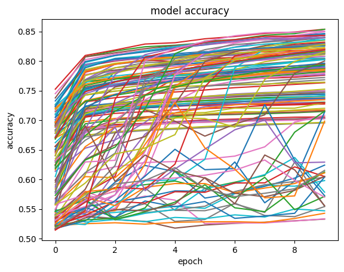

```python
plot_accuracy(resultados_p1["history"], resultados_p1["names"], "_p1_")
```

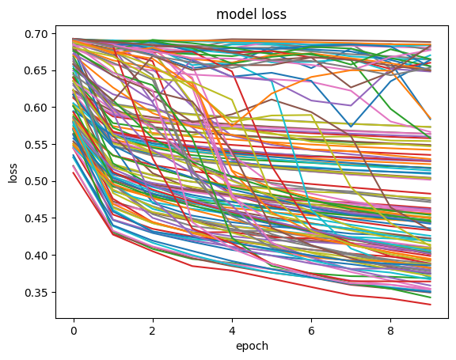

```python
plot_loss(resultados_p1["history"], resultados_p1["names"], "_p1_")
```

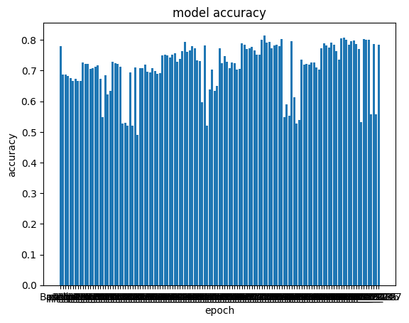

```python
plot_test_accuracy(resultados_p1["test_acc"], resultados_p1["names"], "_p1_")
```

```python
resultados_p1["best_test_acc_index"], resultados_p1["best_test_acc"], resultados_p1["best_params"]
```

```
(82,
 0.8152499794960022,
 {'max_tokens': 1000,
  'output_sequence_length': 75,
  'preprocessing': 'lower_and_strip_punctuation',
  'padding': True})
```

Resultados:

Podemos observar las siguientes conclusiones:

- Los modelos que tenían muy poco output_sequence_length, muy poca estandarizacion o muy poco tamaño de vocabulario son los que peor actuan
- Podemos ver que a nivel general hay varios modelos que alcanzan accuracies similares al baseline
- El *mejor modelo* de la prueba 1 alcanza un accuracy en el test de *0.815* lo que supone un incremento de un *3.5% frente al baseline*. Es un incremento suficiente como para no poder ignorarlo.

#### Pruebas con el tipo de recrusión y su tamaño

Vamos a probar como interactuan diferentes capas con diferentes tipos de recursion (RNN, LSTM, ...) con diferentes tamaños [16, 32, 64, 128]

```python
params_p2 = {
    "Recursive_LayerClass": (layers.SimpleRNN, layers.LSTM, layers.GRU),
    "units": (16, 32, 64, 128),
}
Comb_params_p2 = generate_param_combinations(params_p2)
```

```python
resultados_p2 = test_all(Comb_params_p2)
```

```
563/563 ━━━━━━━━━━━━━━━━━━━━ 4s 5ms/step - accuracy: 0.6804 - f1_score: 0.6666 - loss: 0.5862
563/563 ━━━━━━━━━━━━━━━━━━━━ 3s 5ms/step - accuracy: 0.7903 - f1_score: 0.6666 - loss: 0.4541
563/563 ━━━━━━━━━━━━━━━━━━━━ 3s 5ms/step - accuracy: 0.7995 - f1_score: 0.6666 - loss: 0.4321
563/563 ━━━━━━━━━━━━━━━━━━━━ 3s 5ms/step - accuracy: 0.8063 - f1_score: 0.6666 - loss: 0.4178
563/563 ━━━━━━━━━━━━━━━━━━━━ 3s 5ms/step - accuracy: 0.8116 - f1_score: 0.6666 - loss: 0.4061
563/563 ━━━━━━━━━━━━━━━━━━━━ 3s 5ms/step - accuracy: 0.8166 - f1_score: 0.6666 - loss: 0.3986
563/563 ━━━━━━━━━━━━━━━━━━━━ 3s 5ms/step - accuracy: 0.8184 - f1_score: 0.6666 - loss: 0.3926
563/563 ━━━━━━━━━━━━━━━━━━━━ 3s 5ms/step - accuracy: 0.8228 - f1_score: 0.6666 - loss: 0.3864
563/563 ━━━━━━━━━━━━━━━━━━━━ 3s 5ms/step - accuracy: 0.8256 - f1_score: 0.6666 - loss: 0.3824
563/563 ━━━━━━━━━━━━━━━━━━━━ 3s 5ms/step - accuracy: 0.8288 - f1_score: 0.6666 - loss: 0.3763
250/250 ━━━━━━━━━━━━━━━━━━━━ 1s 2ms/step - accuracy: 0.7761 - f1_score: 0.6650 - loss: 0.4949
563/563 ━━━━━━━━━━━━━━━━━━━━ 4s 6ms/step - accuracy: 0.5988 - f1_score: 0.6666 - loss: 0.6384
563/563 ━━━━━━━━━━━━━━━━━━━━ 3s 6ms/step - accuracy: 0.7877 - f1_score: 0.6666 - loss: 0.4616
563/563 ━━━━━━━━━━━━━━━━━━━━ 3s 6ms/step - accuracy: 0.7990 - f1_score: 0.6666 - loss: 0.4356
563/563 ━━━━━━━━━━━━━━━━━━━━ 3s 6ms/step - accuracy: 0.8044 - f1_score: 0.6666 - loss: 0.4203
563/563 ━━━━━━━━━━━━━━━━━━━━ 3s 6ms/step - accuracy: 0.8089 - f1_score: 0.6666 - loss: 0.4098
563/563 ━━━━━━━━━━━━━━━━━━━━ 3s 6ms/step - accuracy: 0.8157 - f1_score: 0.6666 - loss: 0.4012
563/563 ━━━━━━━━━━━━━━━━━━━━ 3s 6ms/step - accuracy: 0.8179 - f1_score: 0.6666 - loss: 0.3962
563/563 ━━━━━━━━━━━━━━━━━━━━ 3s 6ms/step - accuracy: 0.8183 - f1_score: 0.6666 - loss: 0.3941
563/563 ━━━━━━━━━━━━━━━━━━━━ 3s 5ms/step - accuracy: 0.8221 - f1_score: 0.6666 - loss: 0.3897
563/563 ━━━━━━━━━━━━━━━━━━━━ 3s 5ms/step - accuracy: 0.8272 - f1_score: 0.6666 - loss: 0.3843
250/250 ━━━━━━━━━━━━━━━━━━━━ 1s 2ms/step - accuracy: 0.7729 - f1_score: 0.6650 - loss: 0.4664
563/563 ━━━━━━━━━━━━━━━━━━━━ 4s 6ms/step - accuracy: 0.5749 - f1_score: 0.6666 - loss: 0.6705
563/563 ━━━━━━━━━━━━━━━━━━━━ 3s 6ms/step - accuracy: 0.7744 - f1_score: 0.6666 - loss: 0.4805
563/563 ━━━━━━━━━━━━━━━━━━━━ 3s 6ms/step - accuracy: 0.7950 - f1_score: 0.6666 - loss: 0.4432
563/563 ━━━━━━━━━━━━━━━━━━━━ 3s 6ms/step - accuracy: 0.7998 - f1_score: 0.6666 - loss: 0.4350
563/563 ━━━━━━━━━━━━━━━━━━━━ 3s 6ms/step - accuracy: 0.8044 - f1_score: 0.6666 - loss: 0.4236
563/563 ━━━━━━━━━━━━━━━━━━━━ 3s 6ms/step - accuracy: 0.8080 - f1_score: 0.6666 - loss: 0.4206
563/563 ━━━━━━━━━━━━━━━━━━━━ 3s 6ms/step - accuracy: 0.8127 - f1_score: 0.6666 - loss: 0.4116
563/563 ━━━━━━━━━━━━━━━━━━━━ 3s 6ms/step - accuracy: 0.8179 - f1_score: 0.6666 - loss: 0.4031
563/563 ━━━━━━━━━━━━━━━━━━━━ 3s 6ms/step - accuracy: 0.8223 - f1_score: 0.6666 - loss: 0.3949
563/563 ━━━━━━━━━━━━━━━━━━━━ 3s 6ms/step - accuracy: 0.8285 - f1_score: 0.6666 - loss: 0.3853
250/250 ━━━━━━━━━━━━━━━━━━━━ 1s 2ms/step - accuracy: 0.7902 - f1_score: 0.6650 - loss: 0.4470
563/563 ━━━━━━━━━━━━━━━━━━━━ 6s 9ms/step - accuracy: 0.5486 - f1_score: 0.6666 - loss: 0.6819
563/563 ━━━━━━━━━━━━━━━━━━━━ 5s 10ms/step - accuracy: 0.5633 - f1_score: 0.6666 - loss: 0.6781
563/563 ━━━━━━━━━━━━━━━━━━━━ 5s 10ms/step - accuracy: 0.6437 - f1_score: 0.6666 - loss: 0.6392
563/563 ━━━━━━━━━━━━━━━━━━━━ 5s 10ms/step - accuracy: 0.7106 - f1_score: 0.6666 - loss: 0.5632
563/563 ━━━━━━━━━━━━━━━━━━━━ 5s 10ms/step - accuracy: 0.7786 - f1_score: 0.6666 - loss: 0.4849
563/563 ━━━━━━━━━━━━━━━━━━━━ 5s 10ms/step - accuracy: 0.7929 - f1_score: 0.6666 - loss: 0.4590
563/563 ━━━━━━━━━━━━━━━━━━━━ 5s 10ms/step - accuracy: 0.7980 - f1_score: 0.6666 - loss: 0.4506
```

[output cut: 77 more lines]

```
563/563 ━━━━━━━━━━━━━━━━━━━━ 10s 17ms/step - accuracy: 0.8346 - f1_score: 0.6666 - loss: 0.3621
563/563 ━━━━━━━━━━━━━━━━━━━━ 10s 17ms/step - accuracy: 0.8382 - f1_score: 0.6666 - loss: 0.3538
563/563 ━━━━━━━━━━━━━━━━━━━━ 10s 17ms/step - accuracy: 0.8426 - f1_score: 0.6666 - loss: 0.3461
250/250 ━━━━━━━━━━━━━━━━━━━━ 1s 3ms/step - accuracy: 0.8316 - f1_score: 0.6650 - loss: 0.3733
563/563 ━━━━━━━━━━━━━━━━━━━━ 19s 32ms/step - accuracy: 0.6068 - f1_score: 0.6666 - loss: 0.6314
563/563 ━━━━━━━━━━━━━━━━━━━━ 18s 32ms/step - accuracy: 0.7946 - f1_score: 0.6666 - loss: 0.4383
563/563 ━━━━━━━━━━━━━━━━━━━━ 18s 32ms/step - accuracy: 0.8133 - f1_score: 0.6666 - loss: 0.4041
563/563 ━━━━━━━━━━━━━━━━━━━━ 18s 32ms/step - accuracy: 0.8201 - f1_score: 0.6666 - loss: 0.3907
563/563 ━━━━━━━━━━━━━━━━━━━━ 18s 32ms/step - accuracy: 0.8246 - f1_score: 0.6666 - loss: 0.3835
563/563 ━━━━━━━━━━━━━━━━━━━━ 18s 32ms/step - accuracy: 0.8281 - f1_score: 0.6666 - loss: 0.3763
563/563 ━━━━━━━━━━━━━━━━━━━━ 18s 32ms/step - accuracy: 0.8317 - f1_score: 0.6666 - loss: 0.3682
563/563 ━━━━━━━━━━━━━━━━━━━━ 18s 32ms/step - accuracy: 0.8364 - f1_score: 0.6666 - loss: 0.3588
563/563 ━━━━━━━━━━━━━━━━━━━━ 20s 32ms/step - accuracy: 0.8416 - f1_score: 0.6666 - loss: 0.3486
563/563 ━━━━━━━━━━━━━━━━━━━━ 18s 32ms/step - accuracy: 0.8469 - f1_score: 0.6666 - loss: 0.3392
250/250 ━━━━━━━━━━━━━━━━━━━━ 1s 4ms/step - accuracy: 0.8280 - f1_score: 0.6650 - loss: 0.3729
```

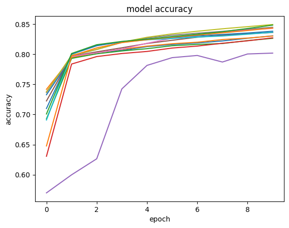

```python
plot_accuracy(resultados_p2["history"], resultados_p2["names"], "_p2_")
```

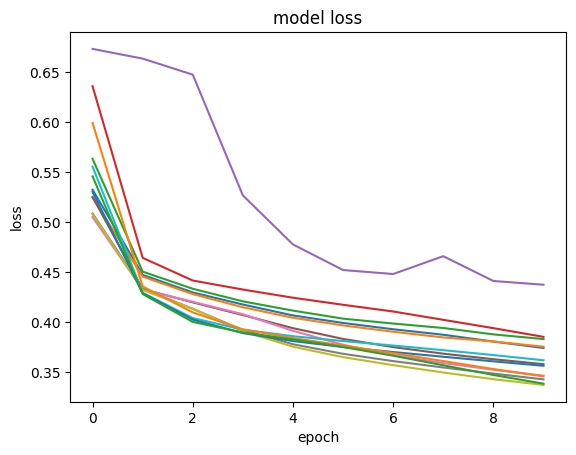

```python
plot_loss(resultados_p2["history"], resultados_p2["names"], "_p2_")
```

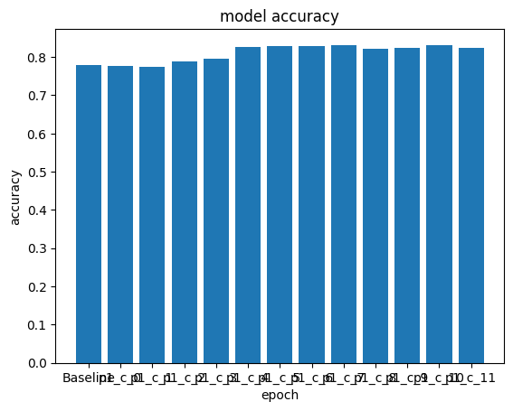

```python
plot_test_accuracy(resultados_p2["test_acc"], resultados_p2["names"], "_p2_")
```

```python
resultados_p2["best_test_acc_index"], resultados_p2["best_test_acc"], resultados_p2["best_params"]
```

```
(11,
 0.8317499756813049,
 {'Recursive_LayerClass': keras.src.layers.rnn.gru.GRU, 'units': 64})
```

Resultados

A diferencia del apartado anterior, donde no se podia observar una tendencia tan clara, en este caso podemos observar una mejora en casi cualquier combinacion de parametros respecto al baseline

- Se observa una tendencia genera en la que la accuracy aumenta y "converge" de manera más rápida al incrementar la complejidad y el tamaño de las capas
- De manera analoga, se puede observar lo mismo con la bajada del loss
- Los incrementos de complejidad y de tamaño acaban convergiendo, es decir, no se observa la tendencia de que aumentar descomunalmente el tamaño merezca la pena porque produce mejoras cada vez menores
- El *mejor modelo* de la prueba 2 alcanza un accuracy en el test de *0.832* lo que supone un incremento de un *5% frente al baseline*. Es un incremento suficiente como para no poder ignorarlo. Es un incremento más notable que con la prueba anterior

#### Dense y dropout

Vamos a realizar prruebas añadiendole capas Dense y metiendole dropout a las capas recursivas para que generalicen mejor

```python
arrays_layers = [
    [ layers.Dense(16, activation="relu"), layers.Dropout(0.1) ],
    [ layers.Dense(16, activation="relu")],
    [ layers.Dense(32, activation="relu"), layers.Dropout(0.1) ],
    [ layers.Dense(32, activation="relu"), layers.Dropout(0.1), layers.Dense(16, activation="relu")],
]
params_p3 = {
    "ExtraLayers": arrays_layers,
    "dropout": (False, 0.1, 0.2, 0.3)
}
Comb_params_p3 = generate_param_combinations(params_p3)
```

```python
resultados_p3 = test_all(Comb_params_p3)
```

```
563/563 ━━━━━━━━━━━━━━━━━━━━ 4s 5ms/step - accuracy: 0.6124 - f1_score: 0.6666 - loss: 0.6305
563/563 ━━━━━━━━━━━━━━━━━━━━ 3s 5ms/step - accuracy: 0.7901 - f1_score: 0.6666 - loss: 0.4560
563/563 ━━━━━━━━━━━━━━━━━━━━ 3s 5ms/step - accuracy: 0.7975 - f1_score: 0.6666 - loss: 0.4364
563/563 ━━━━━━━━━━━━━━━━━━━━ 3s 5ms/step - accuracy: 0.8048 - f1_score: 0.6666 - loss: 0.4219
563/563 ━━━━━━━━━━━━━━━━━━━━ 3s 5ms/step - accuracy: 0.8093 - f1_score: 0.6666 - loss: 0.4108
563/563 ━━━━━━━━━━━━━━━━━━━━ 3s 5ms/step - accuracy: 0.8121 - f1_score: 0.6666 - loss: 0.4051
563/563 ━━━━━━━━━━━━━━━━━━━━ 3s 5ms/step - accuracy: 0.8165 - f1_score: 0.6666 - loss: 0.3957
563/563 ━━━━━━━━━━━━━━━━━━━━ 3s 5ms/step - accuracy: 0.8197 - f1_score: 0.6666 - loss: 0.3900
563/563 ━━━━━━━━━━━━━━━━━━━━ 3s 5ms/step - accuracy: 0.8217 - f1_score: 0.6666 - loss: 0.3879
563/563 ━━━━━━━━━━━━━━━━━━━━ 3s 5ms/step - accuracy: 0.8244 - f1_score: 0.6666 - loss: 0.3814
250/250 ━━━━━━━━━━━━━━━━━━━━ 1s 2ms/step - accuracy: 0.7758 - f1_score: 0.6650 - loss: 0.4939
563/563 ━━━━━━━━━━━━━━━━━━━━ 5s 6ms/step - accuracy: 0.5183 - f1_score: 0.6666 - loss: 0.6929
563/563 ━━━━━━━━━━━━━━━━━━━━ 4s 6ms/step - accuracy: 0.5409 - f1_score: 0.6666 - loss: 0.6867
563/563 ━━━━━━━━━━━━━━━━━━━━ 4s 6ms/step - accuracy: 0.7061 - f1_score: 0.6666 - loss: 0.5826
563/563 ━━━━━━━━━━━━━━━━━━━━ 4s 6ms/step - accuracy: 0.7581 - f1_score: 0.6666 - loss: 0.5177
563/563 ━━━━━━━━━━━━━━━━━━━━ 4s 6ms/step - accuracy: 0.7700 - f1_score: 0.6666 - loss: 0.5006
563/563 ━━━━━━━━━━━━━━━━━━━━ 4s 6ms/step - accuracy: 0.7790 - f1_score: 0.6666 - loss: 0.4824
563/563 ━━━━━━━━━━━━━━━━━━━━ 4s 6ms/step - accuracy: 0.7869 - f1_score: 0.6666 - loss: 0.4750
563/563 ━━━━━━━━━━━━━━━━━━━━ 4s 6ms/step - accuracy: 0.7902 - f1_score: 0.6666 - loss: 0.4696
563/563 ━━━━━━━━━━━━━━━━━━━━ 4s 6ms/step - accuracy: 0.7922 - f1_score: 0.6666 - loss: 0.4637
563/563 ━━━━━━━━━━━━━━━━━━━━ 4s 6ms/step - accuracy: 0.7943 - f1_score: 0.6666 - loss: 0.4590
250/250 ━━━━━━━━━━━━━━━━━━━━ 1s 2ms/step - accuracy: 0.7494 - f1_score: 0.6650 - loss: 0.5313
563/563 ━━━━━━━━━━━━━━━━━━━━ 5s 6ms/step - accuracy: 0.5080 - f1_score: 0.6666 - loss: 0.7204
563/563 ━━━━━━━━━━━━━━━━━━━━ 3s 6ms/step - accuracy: 0.5314 - f1_score: 0.6666 - loss: 0.6911
563/563 ━━━━━━━━━━━━━━━━━━━━ 3s 6ms/step - accuracy: 0.5547 - f1_score: 0.6666 - loss: 0.6849
563/563 ━━━━━━━━━━━━━━━━━━━━ 4s 6ms/step - accuracy: 0.6118 - f1_score: 0.6666 - loss: 0.6673
563/563 ━━━━━━━━━━━━━━━━━━━━ 3s 6ms/step - accuracy: 0.5903 - f1_score: 0.6666 - loss: 0.6701
563/563 ━━━━━━━━━━━━━━━━━━━━ 3s 6ms/step - accuracy: 0.6388 - f1_score: 0.6666 - loss: 0.6479
563/563 ━━━━━━━━━━━━━━━━━━━━ 3s 6ms/step - accuracy: 0.6758 - f1_score: 0.6666 - loss: 0.6113
563/563 ━━━━━━━━━━━━━━━━━━━━ 3s 6ms/step - accuracy: 0.6983 - f1_score: 0.6666 - loss: 0.5881
563/563 ━━━━━━━━━━━━━━━━━━━━ 3s 6ms/step - accuracy: 0.7237 - f1_score: 0.6666 - loss: 0.5592
563/563 ━━━━━━━━━━━━━━━━━━━━ 3s 6ms/step - accuracy: 0.7343 - f1_score: 0.6666 - loss: 0.5556
250/250 ━━━━━━━━━━━━━━━━━━━━ 1s 2ms/step - accuracy: 0.7439 - f1_score: 0.6650 - loss: 0.5415
563/563 ━━━━━━━━━━━━━━━━━━━━ 5s 6ms/step - accuracy: 0.4976 - f1_score: 0.6666 - loss: 0.7167
563/563 ━━━━━━━━━━━━━━━━━━━━ 3s 6ms/step - accuracy: 0.5165 - f1_score: 0.6666 - loss: 0.6947
563/563 ━━━━━━━━━━━━━━━━━━━━ 3s 6ms/step - accuracy: 0.5229 - f1_score: 0.6666 - loss: 0.6923
563/563 ━━━━━━━━━━━━━━━━━━━━ 3s 6ms/step - accuracy: 0.5301 - f1_score: 0.6666 - loss: 0.6915
563/563 ━━━━━━━━━━━━━━━━━━━━ 3s 6ms/step - accuracy: 0.5245 - f1_score: 0.6666 - loss: 0.6915
563/563 ━━━━━━━━━━━━━━━━━━━━ 3s 6ms/step - accuracy: 0.5340 - f1_score: 0.6666 - loss: 0.6906
563/563 ━━━━━━━━━━━━━━━━━━━━ 3s 6ms/step - accuracy: 0.5360 - f1_score: 0.6666 - loss: 0.6904
```

[output cut: 121 more lines]

```
563/563 ━━━━━━━━━━━━━━━━━━━━ 4s 6ms/step - accuracy: 0.6777 - f1_score: 0.6666 - loss: 0.6043
563/563 ━━━━━━━━━━━━━━━━━━━━ 4s 6ms/step - accuracy: 0.6564 - f1_score: 0.6666 - loss: 0.6226
563/563 ━━━━━━━━━━━━━━━━━━━━ 4s 6ms/step - accuracy: 0.7181 - f1_score: 0.6666 - loss: 0.5679
250/250 ━━━━━━━━━━━━━━━━━━━━ 1s 2ms/step - accuracy: 0.6969 - f1_score: 0.6650 - loss: 0.5802
563/563 ━━━━━━━━━━━━━━━━━━━━ 5s 6ms/step - accuracy: 0.4968 - f1_score: 0.6666 - loss: 0.7574
563/563 ━━━━━━━━━━━━━━━━━━━━ 4s 6ms/step - accuracy: 0.5065 - f1_score: 0.6666 - loss: 0.6941
563/563 ━━━━━━━━━━━━━━━━━━━━ 4s 6ms/step - accuracy: 0.5103 - f1_score: 0.6666 - loss: 0.6938
563/563 ━━━━━━━━━━━━━━━━━━━━ 5s 6ms/step - accuracy: 0.5178 - f1_score: 0.6666 - loss: 0.6927
563/563 ━━━━━━━━━━━━━━━━━━━━ 4s 6ms/step - accuracy: 0.5201 - f1_score: 0.6666 - loss: 0.6920
563/563 ━━━━━━━━━━━━━━━━━━━━ 4s 6ms/step - accuracy: 0.5291 - f1_score: 0.6666 - loss: 0.6914
563/563 ━━━━━━━━━━━━━━━━━━━━ 4s 6ms/step - accuracy: 0.5336 - f1_score: 0.6666 - loss: 0.6907
563/563 ━━━━━━━━━━━━━━━━━━━━ 4s 6ms/step - accuracy: 0.5336 - f1_score: 0.6666 - loss: 0.6907
563/563 ━━━━━━━━━━━━━━━━━━━━ 4s 6ms/step - accuracy: 0.5326 - f1_score: 0.6666 - loss: 0.6908
563/563 ━━━━━━━━━━━━━━━━━━━━ 4s 6ms/step - accuracy: 0.5357 - f1_score: 0.6666 - loss: 0.6902
250/250 ━━━━━━━━━━━━━━━━━━━━ 1s 2ms/step - accuracy: 0.5489 - f1_score: 0.6650 - loss: 0.6881
```

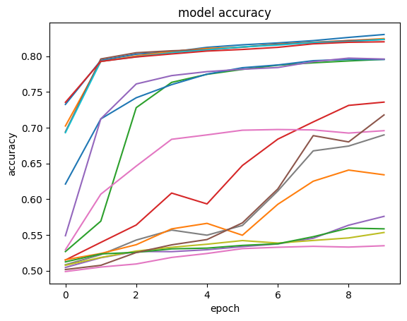

```python
plot_accuracy(resultados_p3["history"], resultados_p3["names"], "_p3_")
```

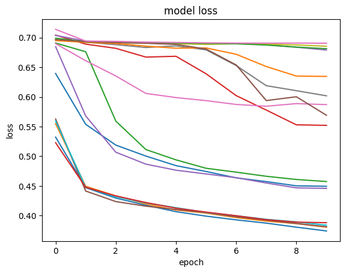

```python
plot_loss(resultados_p3["history"], resultados_p3["names"], "_p3_")
```

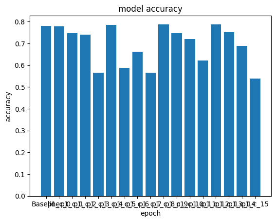

```python
plot_test_accuracy(resultados_p3["test_acc"], resultados_p3["names"], "_p3_")
```

```python
resultados_p3["best_test_acc_index"], resultados_p3["best_test_acc"], resultados_p3["best_params"]
```

```
(13,
 0.7877500057220459,
 {'ExtraLayers': [<Dense name=dense_144, built=True>,
   <Dropout name=dropout_2, built=True>,
   <Dense name=dense_145, built=True>],
  'dropout': False})
```

Resultados

A nivel de resultaods podemos ver los siguiente:

- El meter las capas y el dropout, sobre todo con un tamaño de units de 16 por defecto, genera resultados raros
- La mejor combinación nos ha dado un *0.788* de precision en test, apenas un *0.5%* mejor que la baseline, por lo que no podemos decir que sea extremandamente relevante
- El dropout en papel funciona para generalizar, en este caso al ser los units tan pequeños no parece ayudar, pro con pruebas para tamaños más grandes el dropout si que ayuda a generalizar

#### Cambiar el optimizador

Vamos a probar a cambiar el optimizador a AdamW y a probar a bajar el learningrate en las iteraciones en las que se queda estancado

```python
class modeloBasicoMasOptimizador:
    """
    Modelo básico con los parametros que se indican en el pdf pero con otro optimizador

        - max_tokens: tamaño de vocabulario
        - output_sequence_length: tamaño maximo del texto de entrada
        - output_dim: dimensiones de salida de la capa de embeddings
        - units: numero de unidades de la capa recursiba
        - vocab: vocabulario al que adaptar la capa de vectorizacion de texto
    """
    def __init__(self,
                 max_tokens = 1000,
                 output_sequence_length = 50,
                 output_dim = 16,
                 units = 16,
                 vocab = None
                 ) -> None:
        self._tokenizer_l = layers.TextVectorization(
            max_tokens=max_tokens,
            output_sequence_length= output_sequence_length,
        )
        self._tokenizer_l.adapt(vocab)
        self._embedding_l = layers.Embedding(
            input_dim=max_tokens,
            output_dim=output_dim
        )
        self._rnn_l = layers.SimpleRNN(
            units=units,
        )
        self._dense_l = layers.Dense(1, activation="sigmoid")
        self.model = keras.Sequential(
            [self._tokenizer_l, self._embedding_l, self._rnn_l, self._dense_l]
        )

        """
        Usamos el optimizador AdamW, a mayores, hacemos que en las iteraciones en las que
        empirizamente se nos queda atascado el modelo se le baje el learning rate para que
        siga aprendiendo
        """

        lr = PiecewiseConstantDecay([563*3, 563*7], [0.01, 0.001, 0.0001])
        opt = AdamW(learning_rate=lr)
        self.model.compile(
            optimizer = opt,
            loss="binary_crossentropy",
            metrics=["accuracy", keras.metrics.F1Score]
        )

    def summary(self):
        """
        Devuelve el summary de las capas del modelo
        """
        return self.model.summary()

    def fit(self, X, Y, epochs = 10, batch_size = 128):
        """
        Hace el fitting del modelo en base a X e Y. Devuelve el histórico del entrenamiento
        """
        return self.model.fit(
            X, Y,
            epochs=epochs,
            batch_size=batch_size,
        )

    def test(self, X_test, Y_test):
        """
        Devuelve el accuracy del test
        """
        #devuelve [loss, acc, extras] emtonces nos quedamos con el accuracy del test :D
        return self.model.evaluate(X_test, Y_test)[1]
```

```python
modelo_optimizador = modeloBasicoMasOptimizador(vocab=X)
resultados_optimizador = modelo_optimizador.fit(X, Y)
resultados_test_optimizador = modelo_optimizador.test(X_test, Y_test)
```

```
563/563 ━━━━━━━━━━━━━━━━━━━━ 4s 5ms/step - accuracy: 0.5306 - f1_score: 0.6666 - loss: 0.6906
563/563 ━━━━━━━━━━━━━━━━━━━━ 3s 5ms/step - accuracy: 0.5843 - f1_score: 0.6666 - loss: 0.6697
563/563 ━━━━━━━━━━━━━━━━━━━━ 3s 5ms/step - accuracy: 0.5772 - f1_score: 0.6666 - loss: 0.6759
563/563 ━━━━━━━━━━━━━━━━━━━━ 3s 5ms/step - accuracy: 0.6186 - f1_score: 0.6666 - loss: 0.6565
563/563 ━━━━━━━━━━━━━━━━━━━━ 3s 5ms/step - accuracy: 0.6275 - f1_score: 0.6666 - loss: 0.6454
563/563 ━━━━━━━━━━━━━━━━━━━━ 3s 5ms/step - accuracy: 0.6313 - f1_score: 0.6666 - loss: 0.6409
563/563 ━━━━━━━━━━━━━━━━━━━━ 3s 5ms/step - accuracy: 0.6381 - f1_score: 0.6666 - loss: 0.6387
563/563 ━━━━━━━━━━━━━━━━━━━━ 3s 5ms/step - accuracy: 0.6377 - f1_score: 0.6666 - loss: 0.6324
563/563 ━━━━━━━━━━━━━━━━━━━━ 3s 5ms/step - accuracy: 0.6403 - f1_score: 0.6666 - loss: 0.6278
563/563 ━━━━━━━━━━━━━━━━━━━━ 3s 5ms/step - accuracy: 0.6365 - f1_score: 0.6666 - loss: 0.6302
250/250 ━━━━━━━━━━━━━━━━━━━━ 1s 2ms/step - accuracy: 0.6430 - f1_score: 0.6650 - loss: 0.6342
```

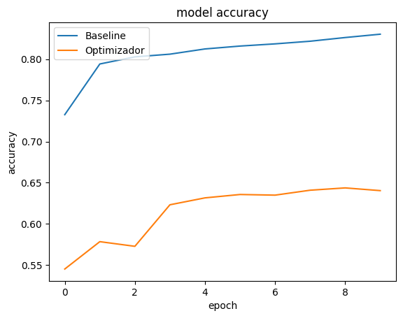

```python
plot_accuracy([Baseline_train, resultados_optimizador], ["Baseline", "Optimizador"], "opt")
```

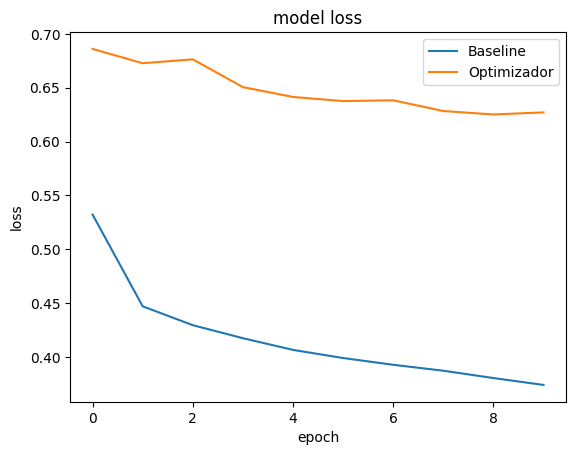

```python
plot_loss([Baseline_train, resultados_optimizador], ["Baseline", "Optimizador"], "opt")
```

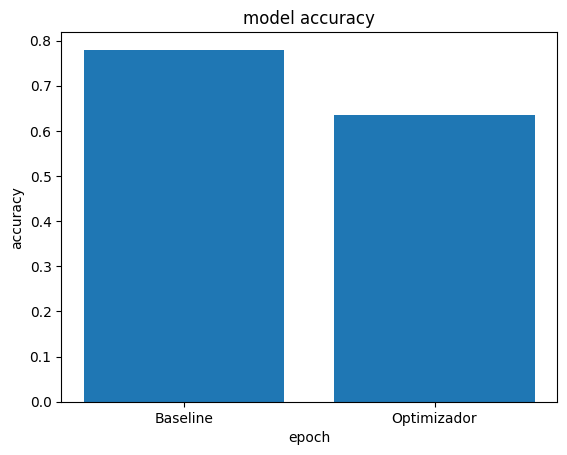

```python
plot_test_accuracy([Baseline_test, resultados_test_optimizador], ["Baseline", "Optimizador"], "opt")
```

```python
resultados_test_optimizador
```

```
0.6340000033378601
```

Resultados

- Podemos observar que para nuestro caso, almenos con la versión original, el empleo de AdamW no es óptimo. Es posible que necesite más epocas para salir del calentamiento o que se ajuste alguno de sus parámetros
- El ajuste de learning rate se ve eclipsado por el AdamW, sin embargo de pruebas anteriores y los resultados del apartado de imágenes, podemos decir que no es mala idea implementarlo

### Prueba Mejor Combinación

A continuación la prueba con la mejor combinación

```python
class modeloConMejorasBasicoYLearningRate:
    """
    Modelo diseñado para variar los parametros. Por defecto los valores son los del
    pdf. Tiene implementado learning rate decay

        - max_tokens: tamaño de vocabulario
        - output_sequence_length: tamaño maximo del texto de entrada
        - padding: indica si hace que el tamaño de salida de la capa de vectorización
        sea siempre el máximo
        - preprocessing: indica el tipo de preprocesamiento hacer en la capa de vectorizacion
        - output_dim: dimensiones de salida de la capa de embeddings
        - units: numero de unidades de la capa recursiba
        - vocab: vocabulario al que adaptar la capa de vectorizacion de texto
        - Recursive_LayerClass: clase que se usa para la recursión del modelo
        - Dropout: indica el dropount de las capas recursivas (por defecto 0)
        - ExtraLayers: array de capas extra a meter antes de la capa que colapsa
        para dos clases
    """
    def __init__(self,
                 max_tokens = 1000,
                 output_sequence_length = 50,
                 padding = False,
                 preprocessing = "lower_and_strip_punctuation",
                 output_dim = 16,
                 units = 16,
                 vocab = None,
                 Recursive_LayerClass = layers.SimpleRNN,
                 dropout = False,
                 ExtraLayers = [],
                 ) -> None:
        self._tokenizer_l = layers.TextVectorization(
            max_tokens=max_tokens,
            output_sequence_length= output_sequence_length,
            standardize = preprocessing,
            pad_to_max_tokens = padding
        )
        self._tokenizer_l.adapt(vocab)

        self._embedding_l = layers.Embedding(
            input_dim=max_tokens,
            output_dim=output_dim
        )

        self._recursive_layer = Recursive_LayerClass(
            units=units,
            recurrent_dropout = dropout if dropout is not None else 0,
            dropout = dropout if dropout is not None else 0,
        )

        self._collapse_layer = layers.Dense(1, activation="sigmoid")

        self.model: keras.Sequential = keras.Sequential(
            [self._tokenizer_l, self._embedding_l, self._recursive_layer, *ExtraLayers, self._collapse_layer]
        )

        lr = PiecewiseConstantDecay([563*3, 563*7], [0.01, 0.001, 0.0001])
        opt = Adam(learning_rate=lr)
        self.model.compile(
            optimizer = opt,
            loss="binary_crossentropy",
            metrics=["accuracy", keras.metrics.F1Score]
        )

    def summary(self):
        """
        Devuelve el summary de las capas del modelo
        """
        return self.model.summary()

    def fit(self, X, Y, epochs = 10, batch_size = 128):
        """
        Hace el fitting del modelo en base a X e Y. Devuelve el histórico del entrenamiento
        """
        return self.model.fit(
            X, Y,
            epochs=epochs,
            batch_size=batch_size,
        )

    def test(self, X_test, Y_test):
        """
        Devuelve el accuracy del test
        """
        #devuelve [loss, acc, extras] emtonces nos quedamos con el accuracy del test :D
        return self.model.evaluate(X_test, Y_test)[1]
```

```python
best_params = {
    'max_tokens': 1000,
    'output_sequence_length': 75,
    'preprocessing': 'lower_and_strip_punctuation',
    'padding': True,
    'Recursive_LayerClass': layers.GRU,
    'units': 64
}
best_model = modeloConMejorasBasico(**best_params, vocab=X)
best_train_res = best_model.fit(X, Y)
best_test_res = best_model.test(X_test, Y_test)
```

```
563/563 ━━━━━━━━━━━━━━━━━━━━ 16s 26ms/step - accuracy: 0.5415 - f1_score: 0.6666 - loss: 0.6833
563/563 ━━━━━━━━━━━━━━━━━━━━ 15s 27ms/step - accuracy: 0.7978 - f1_score: 0.6666 - loss: 0.4387
563/563 ━━━━━━━━━━━━━━━━━━━━ 15s 27ms/step - accuracy: 0.8326 - f1_score: 0.6666 - loss: 0.3721
563/563 ━━━━━━━━━━━━━━━━━━━━ 17s 30ms/step - accuracy: 0.8428 - f1_score: 0.6666 - loss: 0.3546
563/563 ━━━━━━━━━━━━━━━━━━━━ 16s 28ms/step - accuracy: 0.8470 - f1_score: 0.6666 - loss: 0.3479
563/563 ━━━━━━━━━━━━━━━━━━━━ 17s 29ms/step - accuracy: 0.8482 - f1_score: 0.6666 - loss: 0.3437
563/563 ━━━━━━━━━━━━━━━━━━━━ 15s 27ms/step - accuracy: 0.8507 - f1_score: 0.6666 - loss: 0.3398
563/563 ━━━━━━━━━━━━━━━━━━━━ 16s 28ms/step - accuracy: 0.8537 - f1_score: 0.6666 - loss: 0.3345
563/563 ━━━━━━━━━━━━━━━━━━━━ 16s 28ms/step - accuracy: 0.8576 - f1_score: 0.6666 - loss: 0.3268
563/563 ━━━━━━━━━━━━━━━━━━━━ 21s 28ms/step - accuracy: 0.8612 - f1_score: 0.6666 - loss: 0.3174
250/250 ━━━━━━━━━━━━━━━━━━━━ 1s 4ms/step - accuracy: 0.8522 - f1_score: 0.6650 - loss: 0.3289
```

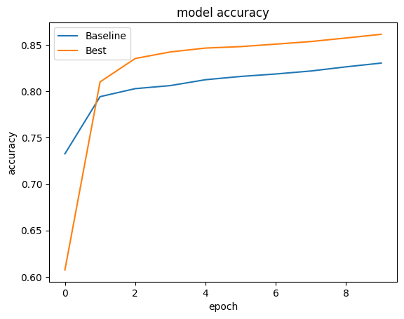

```python
plot_accuracy([Baseline_train, best_train_res], ["Baseline", "Best"], "best")
```

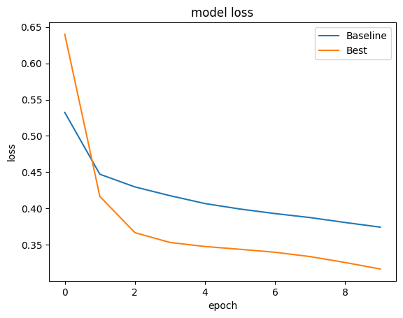

```python
plot_loss([Baseline_train, best_train_res], ["Baseline", "Best"], "best")
```

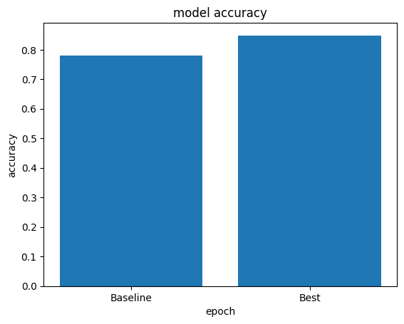

```python
plot_test_accuracy([Baseline_test, best_test_res], ["Baseline", "Best"], "best")
```

```python
best_test_res
```

```
0.8483750224113464
```

Resultados:

Combinando todos los mejores parámetros conseguimos *el mejor modelo*. Este presenta un test_accuracy del *0.848*. Comparado con el *0.78* del baseline supone casi un *7% de mejora frente al baseline*

#### Otros mecanismos

Para este apartado nosotros vamos a crear el bloque recursivo.

```python
from keras import ops

class self_attn(keras.layers.Layer):
    """
    Capa de self attention. Coge la layer de MultiheadAttention ya definida
    en keras y la convierte en self attention haciendo que ambas entradas
    sean los inputs
    """
    def __init__(self, num_heads, embed_dim):
        super().__init__()
        self._mh_attn = tf.keras.layers.MultiHeadAttention(num_heads=num_heads, key_dim=embed_dim)

    def call(self, inputs):
        inputs  = self._mh_attn(inputs, inputs)
        return inputs

class Block(keras.layers.Layer):
    """
    Bloque del pseudo-transformer
    - Coge la atencion de los inputs
    - la suma con los inputs (normaliza y dropea)
    - Coge el feed forward de los inputs (simplificado a una capa dense)
    - lo suma con los inputs (normaliza y dropea)
    """

    def __init__(self, num_heads, embed_dim, dropout):
        super().__init__()
        self._sa = self_attn(num_heads, embed_dim)

        self.ffw = layers.Dense(embed_dim)

        self.dropout1 = layers.Dropout(dropout)
        self.dropout2 = layers.Dropout(dropout)

        self._lyn1 = keras.layers.LayerNormalization(epsilon=1e-6)
        self._lyn2 = keras.layers.LayerNormalization(epsilon=1e-6)

    def call(self, inputs):
        attention = self._sa(inputs)
        attention = self.dropout1(attention)

        inputs = inputs + attention
        inputs = self._lyn1(inputs)

        ffw = self.ffw(inputs)
        ffw = self.dropout2(ffw)

        inputs = inputs + ffw

        inputs = self._lyn2(inputs)

        return inputs

class EncoderBlocks(keras.layers.Layer):
    """
    Capa recursiva, instancia units bloques seguidos para simular
    la recursividad de bloques
    """

    def __init__(self, num_heads, embed_dim, dropout, units):
        super().__init__()
        self._blocks = [Block(num_heads, embed_dim, dropout) for _ in range(units)]

    def call(self, inputs):
        for block in self._blocks:
            inputs = block(inputs)
        return inputs

class PseudoTransformer():
    """
    Traduce el modelo que estaba definido en el pdf a nuestro
    encoder definido a traves de las clases previas
    """
    def __init__(self,
                max_tokens = 1000,
                output_sequence_length = 75,
                padding = False,
                preprocessing = "lower_and_strip_punctuation",
                output_dim = 32,
                units = 8,
                vocab = None,
                dropout = 0.2,
                num_heads = 2,
                ) -> None:

        self._tokenizer_l = layers.TextVectorization(
            max_tokens=max_tokens,
            output_sequence_length= output_sequence_length,
            standardize = preprocessing,
            pad_to_max_tokens = padding
        )
        self._tokenizer_l.adapt(vocab)

        self._embedding_l = layers.Embedding(
            input_dim=max_tokens,
            output_dim=output_dim
        )

        self._blocks = EncoderBlocks(num_heads, output_dim, dropout, units)

        self._collapse_layer = layers.Dense(1, activation="sigmoid")

        self.model: keras.Sequential = keras.Sequential(
            [self._tokenizer_l, self._embedding_l, self._blocks, self._collapse_layer]
        )

        lr = PiecewiseConstantDecay([563*3, 563*7], [0.001, 0.0001, 0.00001])
        opt = AdamW(learning_rate=lr)
        self.model.compile(
            optimizer = opt, loss="binary_crossentropy", metrics=["accuracy"]
        )

    def summary(self):
        """
        Devuelve el summary de las capas del modelo
        """
        return self.model.summary()

    def fit(self, X, Y, epochs = 10, batch_size = 128):
        """
        Hace el fitting del modelo en base a X e Y. Devuelve el histórico del entrenamiento
        """
        return self.model.fit(
            X, Y,
            epochs=epochs,
            batch_size=batch_size,
        )

    def test(self, X_test, Y_test):
        """
        Devuelve el accuracy del test
        """
        #devuelve [loss, acc, extras] emtonces nos quedamos con el accuracy del test :D
        return self.model.evaluate(X_test, Y_test)[1]
```

```python
transformer = PseudoTransformer(vocab=X)
historial_transformer = transformer.fit(X, Y)
```

```
563/563 ━━━━━━━━━━━━━━━━━━━━ 96s 145ms/step - accuracy: 0.5923 - loss: 0.6407
563/563 ━━━━━━━━━━━━━━━━━━━━ 81s 144ms/step - accuracy: 0.8157 - loss: 0.4055
563/563 ━━━━━━━━━━━━━━━━━━━━ 81s 144ms/step - accuracy: 0.8205 - loss: 0.3930
563/563 ━━━━━━━━━━━━━━━━━━━━ 93s 166ms/step - accuracy: 0.8260 - loss: 0.3802
563/563 ━━━━━━━━━━━━━━━━━━━━ 88s 155ms/step - accuracy: 0.8273 - loss: 0.3756
563/563 ━━━━━━━━━━━━━━━━━━━━ 89s 158ms/step - accuracy: 0.8282 - loss: 0.3738
563/563 ━━━━━━━━━━━━━━━━━━━━ 81s 143ms/step - accuracy: 0.8294 - loss: 0.3714
563/563 ━━━━━━━━━━━━━━━━━━━━ 81s 143ms/step - accuracy: 0.8301 - loss: 0.3700
563/563 ━━━━━━━━━━━━━━━━━━━━ 81s 143ms/step - accuracy: 0.8311 - loss: 0.3691
563/563 ━━━━━━━━━━━━━━━━━━━━ 81s 143ms/step - accuracy: 0.8310 - loss: 0.3688
```

```python
resultado_transfomer = transformer.test(X_test, Y_test)
```

```
250/250 ━━━━━━━━━━━━━━━━━━━━ 4s 13ms/step - accuracy: 0.8147 - loss: 0.4120
```

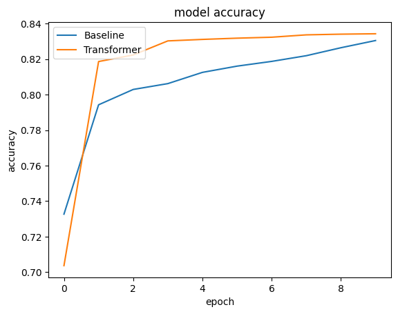

```python
plot_accuracy([Baseline_train, historial_transformer], ["Baseline", "Transformer"], "transformer")
```

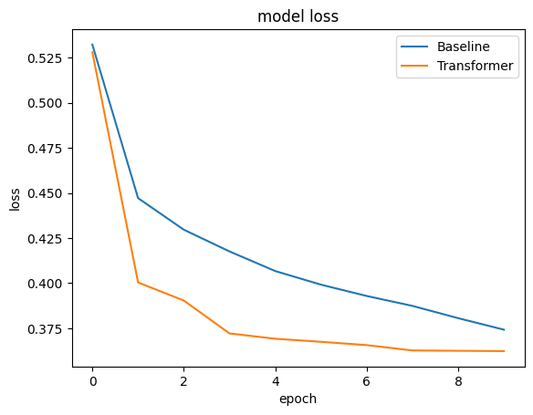

```python
plot_loss([Baseline_train, historial_transformer], ["Baseline", "Transformer"], "transformer")
```

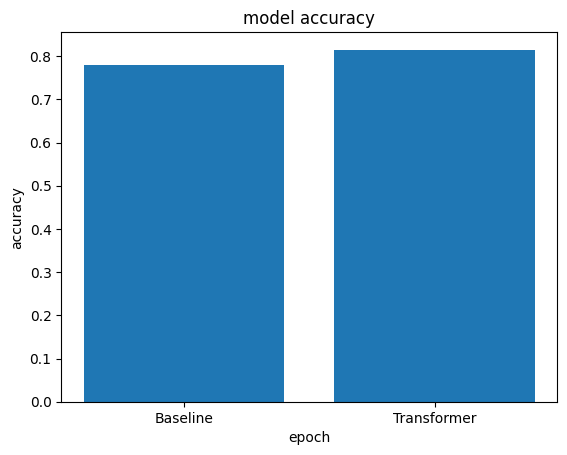

```python
plot_test_accuracy([Baseline_test, resultado_transfomer], ["Baseline", "Transformer"], "transformer")
```

```python
resultado_transfomer
```

```
0.8150197863578796
```

Podemos observar un test_accuracy de *0.815*. No es tan bueno como el mejor que teníamos de antes pero sigue siendo una mejora del *3.5%* respecto del baseline. Debido a las limitaciones computacionales es dificil sacarle el partirdo a esta estructura.